# Face recognition task

We are going to do a face recognition example during this session, because is one of the hottest topics related with Deep Learning and AI, and we are going to see how computational graphs work, and more deeply how a NN works.

## Challenge:

The dataset consists of 1.588 images of either Lionel Messi (534), Neymar (444) or Iniesta (610). The images have been zoomed into the face and cropped to 60x60 pixels. They are all jpg format but some may not actually be Messi or Neymar or even a face as they have been downloaded from the internet with a Google search, most of them however, should be right.

The challenge consists of creating a deep neural network classifier that will discriminate between them. You should get at least 85% accuracy, note that a random classifier would already have a 33% accuracy. The neural network MUST BE IMPLEMENTED WITH TENSORFLOW AND/OR PYTORCH, please do not use other frameworks.

## My Approach:

For this challenge I decided to use a Convolutional Neural Net, because it is a good model for classify images (not the best, but with a good ratio of accuracy simplicity). Also I choosed this because is faster achieving good results with this model than with a Deep Nerual Net (remember from the last sessions that a DNN wastes more memory and a CNN encodes 2D information on the convolutional kernels).

Doing all this job, has taken me 1 day of intensive work.

This is my hardware:

[figure not shown]

## The Code:

First of all we are going to see a simple `tensorflow` implementation of a simple CNN model.

### Loading libraries:

```python
import os
import matplotlib.pyplot as plt
import tensorflow as tf
import pandas as pd
import numpy as np
from datetime import timedelta
```

### Hyper-parameters and Data formatting:

All data is located inside a single folder, so first of all we are going to split the data in 2 dataframes, one for training and one for testing. These dataframes contain the names of the files in one colum, and the ground truth classification in the other column.

The values of the hyper-parameters are usual in CNNs for image recognition. We choose a big `batch_size` to have a less stochastic optimization process.

```python
home = os.path.expanduser("~")
data_folder = os.path.join(home,"Escritorio/face_recognition/fc_data")

os.chdir(data_folder)

# HYPER-PARAMETERS
batch_size = 750
num_epochs = 10
num_channels = 3
learning_r = 0.0005
seed_of_tf = 1
img_size = 60
num_steps = 150
display_step = 10

# step 1 build pre-data in regular python
filenames = [f for f in os.listdir(data_folder)]
labels = []
for el in filenames:
    if "iniesta" in el:
        labels.append([1,0,0])
    elif "messi" in el:
        labels.append([0,1,0])
    else:
        labels.append([0,0,1])

print("\nImage names")
print(filenames[0:32])
print("\nCorresponding Labels")
print(labels[0:32])


## Build training and validation structure
data = pd.DataFrame(filenames,columns=["Names"])
data["Label"] = labels

np.random.seed(2)

T_indexes = np.random.choice(len(filenames),int(0.8*len(filenames)),replace=False)

T_data = data.iloc()[T_indexes]
V_data = data.drop(T_indexes)

T_filenames,T_labels = T_data["Names"].tolist(),T_data["Label"].tolist()
V_filenames,V_labels = V_data["Names"].tolist(),V_data["Label"].tolist()
```

```
Image names
['fcbneymar9.jpg', 'neymarbarcelona71.jpg', 'neymarface3.jpg', 'iniestaseleccion9.jpg', 'iniestaface24.jpg', 'goalneymar11.jpg', 'iniestaface47.jpg', 'jrNeymar86*.jpg', 'iniesta48.jpg', 'iniestagoal80.jpg', 'iniesta22.jpg', 'fcbleomessi94.jpg', 'lionelmessi26.jpg', 'iniestaface12.jpg', 'neymarjrfcb8…

Corresponding Labels
[[0, 0, 1], [0, 0, 1], [0, 0, 1], [1, 0, 0], [1, 0, 0], [0, 0, 1], [1, 0, 0], [0, 0, 1], [1, 0, 0], [1, 0, 0], [1, 0, 0], [0, 1, 0], [0, 1, 0], [1, 0, 0], [0, 0, 1], [0, 1, 0], [0, 0, 1], [1, 0, 0], [0, 1, 0], [0, 0, 1], [0, 1, 0], [0, 1, 0], [0, 1, 0], [1, 0, 0], [0, 0, 1], [0, 1, 0], [1, 0, 0], [0…
```

So now we have our initial data, verified, and we are ready to pass these data to `tensorflow` which is not trivial and has changed in the API 1.4. After that we will build a model that process this data, and learns the internal features to predict the corresponding labels.

### Computational graph and internal checking:

We are going to use `tf.data.Dataset` structure, because of its performance and parallelized queue system. After having these structures formatted to execute train and validation operations, we perform a check on our data to see if everything is flowing well in our graph.

```
Verifying tensor shapes
(750, 60, 60, 3)
(750, 3)

Verfiying image,label correspondence
```

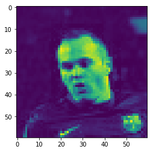

```
[1 0 0]
```

```python
with tf.device("/cpu:0"):
    tf.set_random_seed(seed_of_tf)
    # step 2: create a dataset returning slices of `filenames`
    T_dataset = tf.data.Dataset.from_tensor_slices((T_filenames,T_labels))
    V_dataset = tf.data.Dataset.from_tensor_slices((V_filenames,V_labels))

    # step 3: parse every image in the dataset using `map`
    def _parse_function(filename,label):
        #filename_print = tf.Print(filename,[filename])
        image_string = tf.read_file(filename)
        image_decoded = tf.image.decode_jpeg(image_string, channels=3)
        image = tf.cast(image_decoded, tf.float32)
        return image,label

    T_dataset = T_dataset.map(_parse_function)
    V_dataset = V_dataset.map(_parse_function)

    #dataset = dataset.shuffle(buffer_size=10000)
    T_dataset = T_dataset.batch(batch_size)
    V_dataset = V_dataset.batch(1)

    T_dataset = T_dataset.repeat(num_epochs)

    # step 4: create iterator and final input tensor
    T_iterator = T_dataset.make_initializable_iterator()
    X,Y = T_iterator.get_next()

    V_iterator = V_dataset.make_initializable_iterator()
    X_V,Y_V = V_iterator.get_next()


    with tf.Session() as sess:
        sess.run(T_iterator.initializer)

        if True:
            checking_im,checking_l = sess.run([X,Y])
            print("\nVerifying tensor shapes")
            print(checking_im.shape)
            print(checking_l.shape)
            print("\nVerfiying image,label correspondence")
            imgplot = plt.imshow(checking_im[4,:,:,1])
            label = checking_l[4]
            plt.show()
            print(label)
```

### The model:

Now we can build the model, we are going to use the following tricks:

- Batch normalizaion
- Softmax
- Softmax cross-entropy with logits
- Low number of neurons in FC layer

```python
    def conv_net(x, n_classes, reuse, is_training):
        # Define a scope for reusing the variables
        with tf.variable_scope('ConvNet', reuse=reuse):
            # CHALLENGE data input are images (60*60 pixels)
            # Reshape to match picture format [Height x Width x Channel]
            # Tensor input become 4-D: [Batch Size, Height, Width, Channel]
            x = tf.reshape(x, shape=[-1, img_size, img_size, 3])

            # Convolution Layer with 32 filters and a kernel size of 3
            conv1 = tf.layers.conv2d(x, 32, 5, activation=tf.nn.relu)
            # Max Pooling (down-sampling) with strides of 2 and kernel size of 2
            conv1 = tf.layers.max_pooling2d(conv1, 2, 2)

            # Convolution Layer with 64 filters and a kernel size of 3
            conv2 = tf.layers.conv2d(conv1, 64, 3, activation=tf.nn.relu)
            # Max Pooling (down-sampling) with strides of 2 and kernel size of 2
            conv2 = tf.layers.max_pooling2d(conv2, 2, 2)

            # Convolution Layer with 128 filters and a kernel size of 3
            conv3 = tf.layers.conv2d(conv2, 128, 3, activation=tf.nn.relu)
            # Max Pooling (down-sampling) with strides of 2 and kernel size of 2
            conv3 = tf.layers.max_pooling2d(conv3, 2, 2)

            # Flatten the data to a 1-D vector for the fully connected layer
            fc1 = tf.contrib.layers.flatten(conv3)

            # Fully connected layer (in contrib folder for now)
            fc1 = tf.layers.batch_normalization(fc1)
            fc1 = tf.layers.dense(fc1, 30)#50
            # Apply Dropout (if is_training is False, dropout is not applied)
            #fc1 = tf.layers.dropout(fc1, rate=dropout, training=is_training)

            # Output layer, class prediction
            fc1 = tf.layers.batch_normalization(fc1)
            out = tf.layers.dense(fc1, n_classes)
            # Because 'softmax_cross_entropy_with_logits' already apply softmax,
            # we only apply softmax to testing network
            out = tf.nn.softmax(out) if not is_training else out

        return out

    # Create a graph for training
    logits_train = conv_net(X, 3, reuse=False, is_training=True)
    # Create another graph for testing that reuse the same weights, but has
    # different behavior for 'dropout' (not applied).
    logits_Val = conv_net(X_V, 3, reuse=True, is_training=False)

    # Define loss and optimizer (with train logits, for dropout to take effect)
    loss_op = tf.reduce_mean(tf.nn.softmax_cross_entropy_with_logits(
        logits=logits_train, labels=Y))
    optimizer = tf.train.AdamOptimizer(learning_rate=learning_r)
    train_op = optimizer.minimize(loss_op)

    # Evaluate model (with test logits, for dropout to be disabled)
    correct_pred = tf.equal(tf.argmax(logits_train, 1), tf.argmax(Y, 1))
    accuracy = tf.reduce_mean(tf.cast(correct_pred, tf.float32))

    # Evaluate model (with test logits, for dropout to be disabled)
    correct_pred_V = tf.equal(tf.argmax(logits_Val, 1), tf.argmax(Y_V, 1))
    accuracy_V = tf.reduce_mean(tf.cast(correct_pred_V, tf.float32))

    # Initialize the variables (i.e. assign their default value)
    init = tf.global_variables_initializer()
```

Now we can run the model, with the corresponding printing functions. Notice that this full script can not be executed in python notebook because of the middle `markdown` cells, but you can C+P the code and test it in regular python.

```python
    with tf.Session() as sess:
        # Run the initializer
        sess.run(T_iterator.initializer)
        sess.run(init)

        # Training cycle
        for step in range(1, num_steps + 1):

            try:
                # Run optimization
                sess.run(train_op)
            except tf.errors.OutOfRangeError:
                # Reload the iterator when it reaches the end of the dataset
                sess.run(T_iterator.initializer)
                sess.run(train_op)

            if step % display_step == 0 or step == 1:
                # Calculate batch loss and accuracy
                # (note that this consume a new batch of data)
                loss, acc = sess.run([loss_op, accuracy])
                print("Step " + str(step) + ", Minibatch Loss= " + \
                      "{:.4f}".format(loss) + ", Training Accuracy= " + \
                      "{:.3f}".format(acc))

        print("Optimization Finished!")

        # Validation cycle
        sess.run(V_iterator.initializer)
        acc_val = 0
        for step in range(len(V_data)):
            acc_val = acc_val + sess.run(accuracy_V)

        print("Validation finished with an accuracy of "+str(float(acc_val)/len(V_data)))
```

### Performance and results

Now we can see how all this structure performs using `CPU`. We can see a CNN model with really high performance that classifies faces in 3 categories with around an 87% of validation accuracy (so challenge completed).

[figure not shown]